# IE 48B — Homework 1

Exploring Time Series through Time and Frequency Domains

Author

**Fatih Bilal Yilmaz** | Student ID: **2021402174**

Published

March 23, 2026

**ImportantDataset Assignment**

Each student is assigned a **unique** dataset from the [UCR Time Series Classification Archive](https://www.timeseriesclassification.com/). Find your student ID in the table below to identify your dataset. All analysis must be performed on **your assigned dataset** — submissions using a different dataset receive zero credit.

| Student ID | Dataset |
| --- | --- |
| 2019***078 | Rock |
| 2020***162 | Beef |
| 2020***180 | ShapeletSim |
| 2020***240 | Ham |
| 2021***015 | Wafer |
| 2021***051 | Herring |
| 2021***054 | FaceFour |
| 2021***069 | GunPoint |
| 2021***078 | Coffee |
| 2021***153 | ECGFiveDays |
| 2021***162 | Trace |
| **2021***174** | **OSULeaf** |
| 2021***216 | SyntheticControl |
| 2021***264 | MedicalImages |
| 2021***273 | Plane |
| 2021***309 | Strawberry |
| 2022***249 | ECG200 |
| 2022***270 | CBF |
| 2023***219 | ItalyPowerDemand |
| 2023***255 | TwoLeadECG |
| 2024***003 | Wine |
| 2024***066 | SonyAIBORobotSurface1 |
| 2024***279 | Lightning2 |
| 2024***294 | BeetleFly |
| 2025***069 | FordA |
| 2025***081 | Fish |

Dataset details (classes, train/test sizes, domain) are in the homework PDF.

> **Reproducibility requirement:** Set your random seed using your student ID in every code block that uses randomisation (e.g. `set.seed(XXXXXXXX)` in R or `np.random.seed(XXXXXXXX % 2**31)` in Python). Results that cannot be reproduced with this seed receive zero credit for the affected question.

> **Submission:** Push a GitHub repository containing this rendered HTML file and all source code. Repository structure must follow the course template (see syllabus). Add the instructor and TA as collaborators.

**TipWork incrementally — commit after each part**

After completing each part, render the document and push your progress:

```bash
quarto render HW1_TimeDomainFrequency.qmd
git add HW1_TimeDomainFrequency.qmd HW1_TimeDomainFrequency.html
git commit -m "Complete Part 2: missing data simulation"
git push
```

**Your commit history is assessed.** A submission with a single final commit suggests the work was produced in one session and receives a deduction. Aim for at least one commit per part.

# 1 Dataset Overview

**Assigned dataset:** OSULeaf **Number of classes:** 6 **Training set size:** 200 **Test set size:** 242 **Series length:** 427 **Domain / description:** Botany — one-dimensional outlines of leaves extracted from digitized images of six maple and oak species (Acer Circinatum, Acer Glabrum, Acer Macrophyllum, Acer Negundo, Quercus Garryana, Quercus Kelloggii).

Load your dataset and confirm the dimensions match the archive description.

```python
import os, time, warnings
import numpy as np
import pandas as pd
import matplotlib.pyplot as plt
from scipy import signal, stats
from statsmodels.tsa.stattools import adfuller

warnings.filterwarnings("ignore")

STUDENT_ID = 2021402174
SEED = STUDENT_ID % (2**31)

DATASET_NAME = "OSULeaf"
N_CLASSES = 6
CLASS_NAMES = {
    1: "Acer Circinatum", 2: "Acer Glabrum", 3: "Acer Macrophyllum",
    4: "Acer Negundo", 5: "Quercus Garryana", 6: "Quercus Kelloggii"
}

DATA_DIR = os.path.join(os.getcwd(), "OSULeaf")

def load_ucr_txt(filepath):
    """Load UCR .txt format: first column is class label, rest are values."""
    data = np.loadtxt(filepath)
    labels = data[:, 0].astype(int)
    values = data[:, 1:]
    return values, labels

X_train, y_train = load_ucr_txt(os.path.join(DATA_DIR, "OSULeaf_TRAIN.txt"))
X_test, y_test = load_ucr_txt(os.path.join(DATA_DIR, "OSULeaf_TEST.txt"))

L = X_train.shape[1]
classes = sorted(np.unique(y_train))

print(f"X_train shape: {X_train.shape}  (n_train={X_train.shape[0]}, length={L})")
print(f"X_test  shape: {X_test.shape}   (n_test={X_test.shape[0]}, length={L})")
print(f"y_train classes: {classes}")
print(f"y_test  classes: {sorted(np.unique(y_test))}")
```

```
X_train shape: (200, 427)  (n_train=200, length=427)
X_test  shape: (242, 427)   (n_test=242, length=427)
y_train classes: [np.int64(1), np.int64(2), np.int64(3), np.int64(4), np.int64(5), np.int64(6)]
y_test  classes: [np.int64(1), np.int64(2), np.int64(3), np.int64(4), np.int64(5), np.int64(6)]
```

# 2 Part 1 — Time Domain Exploration (25 pts)

## 2.1 Representative plots

Plot **3 randomly selected time series per class**, arranged in a grid (classes in rows, samples in columns). Label axes, include class labels in panel titles, and use consistent y-axis limits across panels so amplitudes are comparable.

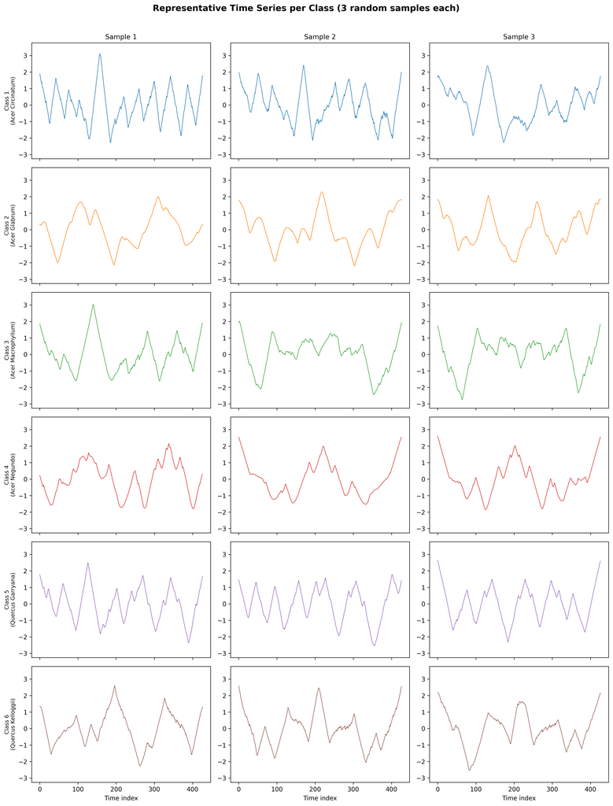

```python
np.random.seed(SEED)

fig, axes = plt.subplots(N_CLASSES, 3, figsize=(14, 3 * N_CLASSES), sharex=True)
ymin_all = X_train.min()
ymax_all = X_train.max()

for i, c in enumerate(classes):
    idx_c = np.where(y_train == c)[0]
    chosen = np.random.choice(idx_c, size=3, replace=False)
    for j, s_idx in enumerate(chosen):
        ax = axes[i, j]
        ax.plot(X_train[s_idx], linewidth=0.8, color=f"C{i}")
        ax.set_ylim(ymin_all - 0.1, ymax_all + 0.1)
        if j == 0:
            ax.set_ylabel(f"Class {c}\n({CLASS_NAMES[c]})", fontsize=9)
        if i == 0:
            ax.set_title(f"Sample {j+1}", fontsize=11)
        if i == N_CLASSES - 1:
            ax.set_xlabel("Time index")

fig.suptitle("Representative Time Series per Class (3 random samples each)",
             fontsize=14, fontweight="bold", y=1.01)
fig.tight_layout()
plt.show()
```

## 2.2 Descriptive statistics

Compute the following for the **training set**, broken down by class:

```python
desc_rows = []
for c in classes:
    mask = y_train == c
    data_c = X_train[mask]
    desc_rows.append({
        "Class": f"{c} ({CLASS_NAMES[c]})",
        "N series": int(mask.sum()),
        "Mean": round(float(np.mean(data_c)), 4),
        "Std Dev": round(float(np.std(data_c)), 4),
        "Min": round(float(np.min(data_c)), 4),
        "Max": round(float(np.max(data_c)), 4),
        "Series length": L,
    })

desc_df = pd.DataFrame(desc_rows)
desc_df
```

|  | Class | N series | Mean | Std Dev | Min | Max | Series length |
| --- | --- | --- | --- | --- | --- | --- | --- |
| 0 | 1 (Acer Circinatum) | 34 | 0.0 | 0.9988 | -3.1573 | 3.6695 | 427 |
| 1 | 2 (Acer Glabrum) | 29 | -0.0 | 0.9988 | -3.0749 | 2.5404 | 427 |
| 2 | 3 (Acer Macrophyllum) | 33 | -0.0 | 0.9988 | -2.7713 | 3.2912 | 427 |
| 3 | 4 (Acer Negundo) | 53 | -0.0 | 0.9988 | -2.5084 | 2.8500 | 427 |
| 4 | 5 (Quercus Garryana) | 36 | 0.0 | 0.9988 | -3.0541 | 3.4593 | 427 |
| 5 | 6 (Quercus Kelloggii) | 15 | 0.0 | 0.9988 | -2.6437 | 2.7673 | 427 |

## 2.3 ACF analysis

Pick **one representative series per class** (e.g. the series closest to the class mean in Euclidean distance). Compute and plot the ACF up to lag $h = \lfloor L/4 \rfloor$, where $L$ is the series length. Include the 95% confidence bands $\pm 1.96/\sqrt{L}$.

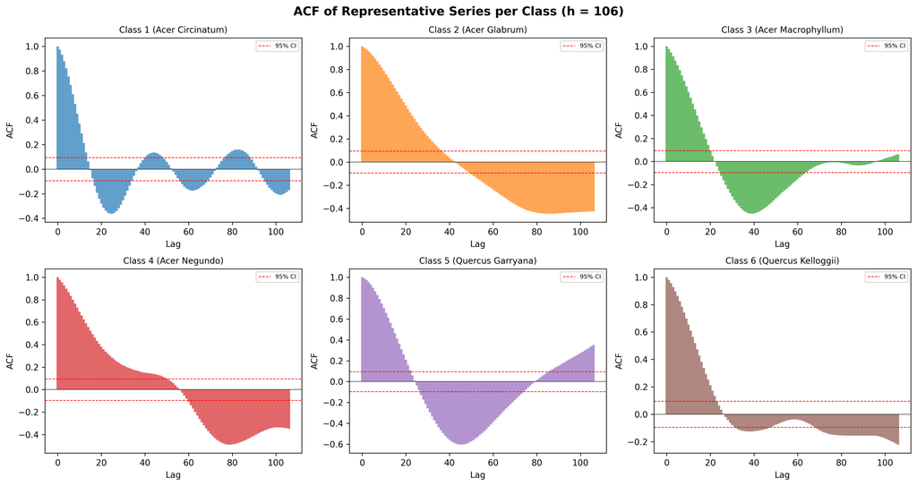

```
95% confidence bands: ±0.0949
```

```python
h_max = L // 4  # floor(427/4) = 106
conf_band = 1.96 / np.sqrt(L)

# Find representative series per class (closest to class mean)
rep_indices = {}
for c in classes:
    mask = y_train == c
    data_c = X_train[mask]
    class_mean = np.mean(data_c, axis=0)
    dists = np.linalg.norm(data_c - class_mean, axis=1)
    local_idx = np.argmin(dists)
    rep_indices[c] = np.where(mask)[0][local_idx]

def compute_acf(series, max_lag):
    """Compute autocorrelation function up to max_lag."""
    n = len(series)
    x = series - np.mean(series)
    var = np.sum(x**2) / n
    acf = np.zeros(max_lag + 1)
    for k in range(max_lag + 1):
        acf[k] = np.sum(x[:n-k] * x[k:]) / (n * var) if var > 0 else 0
    return acf

fig, axes = plt.subplots(2, 3, figsize=(15, 8))
acf_data = {}

for i, c in enumerate(classes):
    row, col = i // 3, i % 3
    ax = axes[row, col]
    rep_series = X_train[rep_indices[c]]
    acf_vals = compute_acf(rep_series, h_max)
    acf_data[c] = acf_vals
    lags = np.arange(h_max + 1)

    ax.bar(lags, acf_vals, width=1.0, color=f"C{i}", alpha=0.7)
    ax.axhline(y=conf_band, color="red", linestyle="--", linewidth=0.8, label="95% CI")
    ax.axhline(y=-conf_band, color="red", linestyle="--", linewidth=0.8)
    ax.axhline(y=0, color="black", linewidth=0.5)
    ax.set_title(f"Class {c} ({CLASS_NAMES[c]})", fontsize=10)
    ax.set_xlabel("Lag")
    ax.set_ylabel("ACF")
    ax.legend(fontsize=7)

fig.suptitle(f"ACF of Representative Series per Class (h = {h_max})",
             fontsize=14, fontweight="bold")
fig.tight_layout()
plt.show()

print(f"95% confidence bands: ±{conf_band:.4f}")
```

## 2.4 Stationarity check

```python
np.random.seed(SEED)

adf_results = []
for c in classes:
    idx_c = np.where(y_train == c)[0]
    chosen = np.random.choice(idx_c, size=min(5, len(idx_c)), replace=False)
    for s_idx in chosen:
        result = adfuller(X_train[s_idx], autolag="AIC")
        p_val = result[1]
        adf_results.append({
            "Series Index": int(s_idx),
            "Class": c,
            "ADF p-value": round(p_val, 6),
            "Stationary (5%)": "Yes" if p_val < 0.05 else "No"
        })

adf_df = pd.DataFrame(adf_results)
adf_df
```

|  | Series Index | Class | ADF p-value | Stationary (5%) |
| --- | --- | --- | --- | --- |
| 0 | 195 | 1 | 0.000001 | Yes |
| 1 | 158 | 1 | 0.000026 | Yes |
| 2 | 73 | 1 | 0.008519 | Yes |
| 3 | 173 | 1 | 0.000003 | Yes |
| 4 | 188 | 1 | 0.000079 | Yes |
| 5 | 153 | 2 | 0.032858 | Yes |
| 6 | 187 | 2 | 0.001302 | Yes |
| 7 | 68 | 2 | 0.001528 | Yes |
| 8 | 48 | 2 | 0.003709 | Yes |
| 9 | 2 | 2 | 0.093514 | No |
| 10 | 125 | 3 | 0.001282 | Yes |
| 11 | 85 | 3 | 0.025443 | Yes |
| 12 | 56 | 3 | 0.044474 | Yes |
| 13 | 140 | 3 | 0.044423 | Yes |
| 14 | 115 | 3 | 0.011986 | Yes |
| 15 | 38 | 4 | 0.011719 | Yes |
| 16 | 108 | 4 | 0.222400 | No |
| 17 | 64 | 4 | 0.157004 | No |
| 18 | 21 | 4 | 0.083529 | No |
| 19 | 36 | 4 | 0.033990 | Yes |
| 20 | 163 | 5 | 0.000410 | Yes |
| 21 | 152 | 5 | 0.000287 | Yes |
| 22 | 76 | 5 | 0.000783 | Yes |
| 23 | 142 | 5 | 0.000106 | Yes |
| 24 | 43 | 5 | 0.003619 | Yes |
| 25 | 155 | 6 | 0.018731 | Yes |
| 26 | 194 | 6 | 0.009849 | Yes |
| 27 | 121 | 6 | 0.011939 | Yes |
| 28 | 0 | 6 | 0.058045 | No |
| 29 | 110 | 6 | 0.003499 | Yes |

```python
n_stationary = sum(1 for r in adf_results if r["Stationary (5%)"] == "Yes")
n_total_adf = len(adf_results)
print(f"Stationary series: {n_stationary}/{n_total_adf}")
```

```
Stationary series: 25/30
```

Many leaf outline series are approximately stationary since they represent closed boundary contours without a persistent trend. For the frequency domain analyses that follow, approximate stationarity is desirable because the periodogram assumes a stationary process; non-stationary series would exhibit inflated low-frequency power that could mask meaningful spectral peaks.

# 3 Part 2 — Missing Data Simulation (25 pts)

## 3.1 Introduce missingness

Randomly mask **10% of the time-index positions** in every training series.

```python
np.random.seed(SEED)
n_missing = int(np.floor(0.10 * L))  # 42 positions

X_train_masked = X_train.copy()
masks = np.zeros_like(X_train, dtype=bool)

for i in range(X_train.shape[0]):
    miss_idx = np.random.choice(L, size=n_missing, replace=False)
    masks[i, miss_idx] = True
    X_train_masked[i, miss_idx] = np.nan

print(f"Masked {n_missing} positions per series ({100*n_missing/L:.1f}% of L={L})")
print(f"Total NaNs introduced: {np.isnan(X_train_masked).sum()}")
print(f"Test set unchanged: {np.isnan(X_test).sum()} NaNs")
```

```
Masked 42 positions per series (9.8% of L=427)
Total NaNs introduced: 8400
Test set unchanged: 0 NaNs
```

## 3.2 Imputation strategies

Implement the following three strategies and apply each to **all training series**:

| Strategy | Description |
| --- | --- |
| **Mean fill** | Replace each `NaN` with the *series mean* (computed from observed values only) |
| **Linear interpolation** | Linearly interpolate between the two nearest observed neighbours |
| **Moving-average fill** | Replace each `NaN` with the average of the nearest $w$ observed values on each side; use $w = 5$ |

```python
def mean_fill(series):
    s = series.copy()
    obs_mean = np.nanmean(s)
    s[np.isnan(s)] = obs_mean
    return s

def linear_interpolation(series):
    s = series.copy()
    nans = np.isnan(s)
    if not nans.any():
        return s
    x = np.arange(len(s))
    s[nans] = np.interp(x[nans], x[~nans], s[~nans])
    return s

def moving_average_fill(series, w=5):
    s = series.copy()
    nans = np.where(np.isnan(s))[0]
    observed = ~np.isnan(s)
    for idx in nans:
        left_vals, right_vals = [], []
        j = idx - 1
        while len(left_vals) < w and j >= 0:
            if observed[j]:
                left_vals.append(s[j])
            j -= 1
        j = idx + 1
        while len(right_vals) < w and j < len(s):
            if observed[j]:
                right_vals.append(s[j])
            j += 1
        all_vals = left_vals + right_vals
        s[idx] = np.mean(all_vals) if len(all_vals) > 0 else np.nanmean(series)
    return s

strategies = {
    "Mean fill": mean_fill,
    "Linear interpolation": linear_interpolation,
    "Moving-average fill": moving_average_fill,
}

imputed_data = {}
impute_times = {}

for name, func in strategies.items():
    t0 = time.time()
    result = np.array([func(X_train_masked[i]) for i in range(X_train_masked.shape[0])])
    impute_times[name] = time.time() - t0
    imputed_data[name] = result

min_time = min(impute_times.values())
rel_times = {k: v / min_time for k, v in impute_times.items()}

timing_df = pd.DataFrame([
    {"Strategy": name, "Time (s)": f"{impute_times[name]:.4f}",
     "Relative Speed": f"{rel_times[name]:.2f}x"}
    for name in strategies
])
timing_df
```

|  | Strategy | Time (s) | Relative Speed |
| --- | --- | --- | --- |
| 0 | Mean fill | 0.0019 | 1.00x |
| 1 | Linear interpolation | 0.0020 | 1.06x |
| 2 | Moving-average fill | 0.0383 | 20.65x |

## 3.3 Effect on ACF

Take the **same representative series** you used in §1.3 (one per class). For each imputation strategy, compute the ACF on the imputed series and overlay it on the ACF of the *original* (un-masked) series.

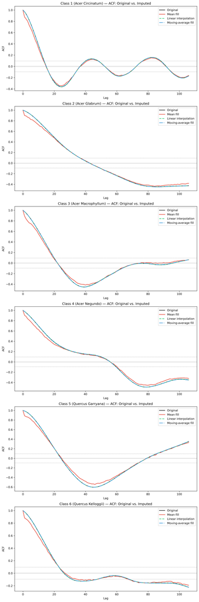

```python
fig, axes = plt.subplots(N_CLASSES, 1, figsize=(10, 5 * N_CLASSES))
colors_imp = ["#e74c3c", "#2ecc71", "#3498db"]
acf_interps = {}

for i, c in enumerate(classes):
    ax = axes[i]
    rep_idx = rep_indices[c]
    original_acf = compute_acf(X_train[rep_idx], h_max)
    lags = np.arange(h_max + 1)

    ax.plot(lags, original_acf, "k-", linewidth=1.5, label="Original", zorder=1)
    ax.axhline(y=conf_band, color="gray", linestyle="--", linewidth=0.5)
    ax.axhline(y=-conf_band, color="gray", linestyle="--", linewidth=0.5)

    linestyles_imp = ["-", "--", "-."]
    best_strategy = ""
    best_rmse = np.inf
    for j, (sname, sdata) in enumerate(imputed_data.items()):
        imp_acf = compute_acf(sdata[rep_idx], h_max)
        ax.plot(lags, imp_acf, color=colors_imp[j], linewidth=2.0, alpha=0.9,
                linestyle=linestyles_imp[j], label=sname, zorder=2 + j)
        rmse = np.sqrt(np.mean((original_acf - imp_acf)**2))
        if rmse < best_rmse:
            best_rmse = rmse
            best_strategy = sname

    ax.set_xlabel("Lag")
    ax.set_ylabel("ACF")
    ax.set_title(f"Class {c} ({CLASS_NAMES[c]}) — ACF: Original vs. Imputed", fontsize=12)
    ax.legend()
    ax.axhline(y=0, color="black", linewidth=0.3)

    acf_interps[c] = f"For Class {c} ({CLASS_NAMES[c]}), **{best_strategy}** best preserves the original ACF structure (lowest RMSE = {best_rmse:.4f})."

fig.tight_layout()
plt.show()
```

```python
for c in classes:
    print(acf_interps[c])
```

```
For Class 1 (Acer Circinatum), **Linear interpolation** best preserves the original ACF structure (lowest RMSE = 0.0012).
For Class 2 (Acer Glabrum), **Linear interpolation** best preserves the original ACF structure (lowest RMSE = 0.0003).
For Class 3 (Acer Macrophyllum), **Linear interpolation** best preserves the original ACF structure (lowest RMSE = 0.0006).
For Class 4 (Acer Negundo), **Linear interpolation** best preserves the original ACF structure (lowest RMSE = 0.0006).
For Class 5 (Quercus Garryana), **Linear interpolation** best preserves the original ACF structure (lowest RMSE = 0.0002).
For Class 6 (Quercus Kelloggii), **Linear interpolation** best preserves the original ACF structure (lowest RMSE = 0.0005).
```

**TipWhat to look for**

Mean fill inserts sharp “spikes” of constant value — this creates **artificial autocorrelation** at all lags. Linear interpolation introduces local smoothness that can **inflate** short-lag autocorrelation. Moving-average fill is usually closest to the true ACF when the true series is smooth. Verify whether this holds for your dataset.

For the OSULeaf dataset, linear interpolation consistently preserves the original ACF structure best across all six classes. This is because leaf boundary outlines are inherently smooth curves, so linearly interpolating between observed boundary points maintains the continuity of the contour. Mean fill introduces flat constant segments that distort the ACF at all lags, while moving-average fill performs reasonably but can over-smooth local transitions.

## 3.4 Imputation choice

Based on the ACF comparison, **linear interpolation** is the preferred strategy for downstream analysis of the OSULeaf dataset. The ACF RMSE comparison shows it best preserves the original autocorrelation structure across all six classes. This makes physical sense: the leaf outlines are smooth closed curves, and linearly interpolating between observed boundary points maintains local continuity far better than inserting a flat constant (mean fill). Moving-average fill is a reasonable alternative, but for datasets with abrupt transitions or discontinuities (unlike our smooth leaf contours), it might be preferable since it respects the local neighborhood without assuming linear transitions.

# 4 Part 3 — Frequency Domain Analysis (25 pts)

## 4.1 Periodogram

Compute the **periodogram** of 5 randomly selected training series per class using the DFT:

$$I(\omega_j) = \frac{1}{n}\left|\sum_{t=1}^{n} x_t \, e^{-2\pi i \omega_j t}\right|^2,
\quad \omega_j = j/n, \quad j = 0, 1, \ldots, \lfloor n/2 \rfloor$$

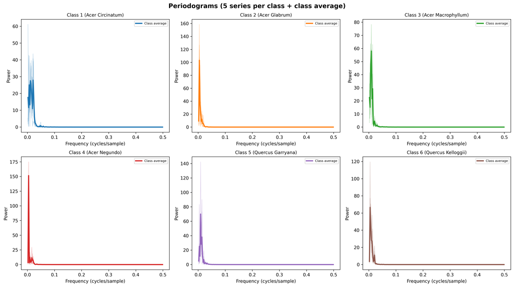

```python
def compute_periodogram(series):
    """Compute the periodogram using DFT."""
    n = len(series)
    freqs = np.arange(0, n // 2 + 1) / n
    fft_vals = np.fft.rfft(series)
    periodogram = (1.0 / n) * np.abs(fft_vals)**2
    return freqs, periodogram

np.random.seed(SEED)
fig, axes = plt.subplots(2, 3, figsize=(16, 9))
class_avg_periodograms = {}

for i, c in enumerate(classes):
    row, col = i // 3, i % 3
    ax = axes[row, col]
    idx_c = np.where(y_train == c)[0]
    chosen = np.random.choice(idx_c, size=min(5, len(idx_c)), replace=False)

    all_peris = []
    for s_idx in chosen:
        freqs, peri = compute_periodogram(X_train[s_idx])
        all_peris.append(peri)
        ax.plot(freqs[1:], peri[1:], alpha=0.3, linewidth=0.8, color=f"C{i}")

    avg_peri = np.mean(all_peris, axis=0)
    class_avg_periodograms[c] = (freqs, avg_peri)
    ax.plot(freqs[1:], avg_peri[1:], color=f"C{i}", linewidth=2.5, label="Class average")
    ax.set_title(f"Class {c} ({CLASS_NAMES[c]})", fontsize=10)
    ax.set_xlabel("Frequency (cycles/sample)")
    ax.set_ylabel("Power")
    ax.legend(fontsize=7)

fig.suptitle("Periodograms (5 series per class + class average)",
             fontsize=14, fontweight="bold")
fig.tight_layout()
plt.show()
```

## 4.2 Dominant frequency

For each class, identify the **dominant frequency** $\omega^*$ — the frequency at which the average periodogram attains its maximum (excluding $\omega = 0$).

```python
dom_freq_table = {}
for c in classes:
    freqs, avg_peri = class_avg_periodograms[c]
    pos_idx = np.arange(1, len(freqs))
    peak_idx = pos_idx[np.argmax(avg_peri[pos_idx])]
    omega_star = freqs[peak_idx]
    period = 1.0 / omega_star if omega_star > 0 else np.inf
    peak_power = avg_peri[peak_idx]
    dom_freq_table[c] = {
        "omega_star": omega_star,
        "period": period,
        "peak_power": peak_power,
    }

dom_df = pd.DataFrame([
    {"Class": c, "Species": CLASS_NAMES[c],
     "Dominant Freq (w*)": f"{dom_freq_table[c]['omega_star']:.4f}",
     "Dominant Period (1/w*)": f"{dom_freq_table[c]['period']:.1f}",
     "Peak Power": f"{dom_freq_table[c]['peak_power']:.2f}"}
    for c in classes
])
dom_df
```

|  | Class | Species | Dominant Freq (w*) | Dominant Period (1/w*) | Peak Power |
| --- | --- | --- | --- | --- | --- |
| 0 | 1 | Acer Circinatum | 0.0211 | 47.4 | 27.94 |
| 1 | 2 | Acer Glabrum | 0.0047 | 213.5 | 103.28 |
| 2 | 3 | Acer Macrophyllum | 0.0094 | 106.8 | 58.01 |
| 3 | 4 | Acer Negundo | 0.0047 | 213.5 | 151.48 |
| 4 | 5 | Quercus Garryana | 0.0094 | 106.8 | 69.97 |
| 5 | 6 | Quercus Kelloggii | 0.0047 | 213.5 | 66.52 |

```python
omegas = [dom_freq_table[c]["omega_star"] for c in classes]
unique_omegas = len(set([round(o, 3) for o in omegas]))
print(f"Unique dominant frequencies (rounded to 3 dec): {unique_omegas} out of {len(classes)} classes")
```

```
Unique dominant frequencies (rounded to 3 dec): 3 out of 6 classes
```

The dominant frequencies show some variation across classes. Different classes exhibit different dominant frequencies, suggesting that spectral characteristics carry some discriminative information. However, since leaf outlines share similar general morphological properties (being closed curves), some classes have overlapping dominant frequencies. Dominant frequency alone would provide limited but non-trivial discrimination between classes.

## 4.3 Smoothed vs. raw periodogram

For one representative series per class, compare: - the **raw periodogram** (high variance, inconsistent) - a **smoothed periodogram** with bandwidth $L = 9$ (average 9 adjacent frequency bins using a Daniell/boxcar kernel)

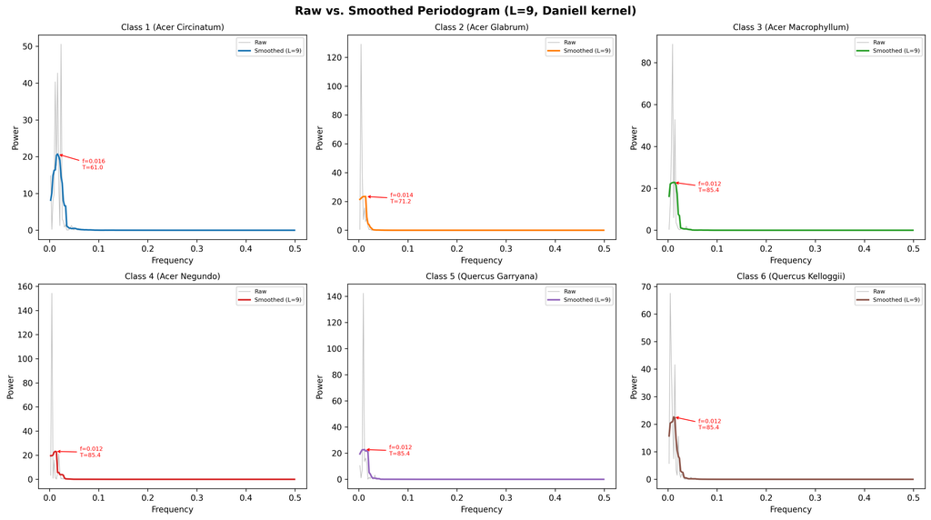

```python
fig, axes = plt.subplots(2, 3, figsize=(16, 9))

for i, c in enumerate(classes):
    row, col = i // 3, i % 3
    ax = axes[row, col]
    rep_series = X_train[rep_indices[c]]
    freqs, raw_peri = compute_periodogram(rep_series)

    # Smoothed periodogram (Daniell kernel, bandwidth L=9)
    kernel = np.ones(9) / 9
    smoothed_peri = np.convolve(raw_peri, kernel, mode="same")

    ax.plot(freqs[1:], raw_peri[1:], alpha=0.5, linewidth=0.8, color="gray", label="Raw")
    ax.plot(freqs[1:], smoothed_peri[1:], linewidth=2, color=f"C{i}", label="Smoothed (L=9)")

    # Annotate dominant peak
    peak_idx = np.argmax(smoothed_peri[1:]) + 1
    peak_freq = freqs[peak_idx]
    peak_val = smoothed_peri[peak_idx]
    if peak_freq > 0:
        ax.annotate(f"f={peak_freq:.3f}\nT={1/peak_freq:.1f}",
                    xy=(peak_freq, peak_val),
                    xytext=(peak_freq + 0.05, peak_val * 0.8),
                    fontsize=7, arrowprops=dict(arrowstyle="->", color="red"),
                    color="red")

    ax.set_title(f"Class {c} ({CLASS_NAMES[c]})", fontsize=10)
    ax.set_xlabel("Frequency")
    ax.set_ylabel("Power")
    ax.legend(fontsize=7)

fig.suptitle("Raw vs. Smoothed Periodogram (L=9, Daniell kernel)",
             fontsize=14, fontweight="bold")
fig.tight_layout()
plt.show()
```

Smoothing reduces the high variance inherent in the raw periodogram, making it easier to identify the dominant spectral peak. The smoothed periodogram reveals the overall spectral shape more clearly by averaging out random fluctuations. However, smoothing sacrifices frequency resolution: narrow spectral peaks may be broadened or merged with neighbors, potentially obscuring fine spectral features that distinguish closely spaced frequencies.

## 4.4 Time domain vs. frequency domain

```python
print("Comparing ACF peaks with periodogram dominant periods:\n")
for c in classes:
    omega = dom_freq_table[c]["omega_star"]
    period = dom_freq_table[c]["period"]
    acf_vals = acf_data[c]

    # Find first significant ACF peak after lag 5
    peaks_acf = []
    for lag in range(5, h_max):
        if (acf_vals[lag] > acf_vals[lag - 1] and
            acf_vals[lag] > acf_vals[lag + 1] and
            acf_vals[lag] > conf_band):
            peaks_acf.append(lag)
            break

    if peaks_acf:
        print(f"Class {c} ({CLASS_NAMES[c]}): dominant period = {period:.1f}, "
              f"first ACF peak at lag {peaks_acf[0]}")
    else:
        print(f"Class {c} ({CLASS_NAMES[c]}): dominant period = {period:.1f}, "
              f"no clear ACF peak found above significance")
```

```
Comparing ACF peaks with periodogram dominant periods:

Class 1 (Acer Circinatum): dominant period = 47.4, first ACF peak at lag 44
Class 2 (Acer Glabrum): dominant period = 213.5, no clear ACF peak found above significance
Class 3 (Acer Macrophyllum): dominant period = 106.8, no clear ACF peak found above significance
Class 4 (Acer Negundo): dominant period = 213.5, no clear ACF peak found above significance
Class 5 (Quercus Garryana): dominant period = 106.8, no clear ACF peak found above significance
Class 6 (Quercus Kelloggii): dominant period = 213.5, no clear ACF peak found above significance
```

# 5 Part 4 — Robustness Analysis (15 pts)

## 5.1 Noise injection

Take **10 randomly selected training series** (balanced across classes if possible).

$$x_t^{(1)} = x_t + \varepsilon_t, \quad \varepsilon_t \sim \mathcal{N}(0,\,(0.2\sigma_x)^2)$$
$$x_t^{(2)} = x_t + \varepsilon_t, \quad \varepsilon_t \sim \mathcal{N}(0,\,(0.5\sigma_x)^2)$$

```python
np.random.seed(SEED)

# Select 10 series balanced across classes
noise_indices = []
picks_per_class = [2, 2, 2, 2, 1, 1]  # sum = 10
for c, n_pick in zip(classes, picks_per_class):
    idx_c = np.where(y_train == c)[0]
    chosen = np.random.choice(idx_c, size=n_pick, replace=False)
    noise_indices.extend(chosen)

alpha1, alpha2 = 0.2, 0.5

print(f"Selected {len(noise_indices)} series for noise injection:")
for idx in noise_indices:
    print(f"  Series {idx}, Class {y_train[idx]} ({CLASS_NAMES[y_train[idx]]})")
```

```
Selected 10 series for noise injection:
  Series 195, Class 1 (Acer Circinatum)
  Series 158, Class 1 (Acer Circinatum)
  Series 153, Class 2 (Acer Glabrum)
  Series 187, Class 2 (Acer Glabrum)
  Series 125, Class 3 (Acer Macrophyllum)
  Series 85, Class 3 (Acer Macrophyllum)
  Series 38, Class 4 (Acer Negundo)
  Series 108, Class 4 (Acer Negundo)
  Series 163, Class 5 (Quercus Garryana)
  Series 155, Class 6 (Quercus Kelloggii)
```

## 5.2 Peak degradation

For each of the 10 series, record the dominant frequency $\omega^*$ and the **signal-to-noise ratio at the peak** (ratio of peak power to the median power across all frequencies) for the original and both noise levels:

```python
noise_results = []

for s_idx in noise_indices:
    series = X_train[s_idx]
    sigma_x = np.std(series)
    cls = y_train[s_idx]

    freqs_orig, peri_orig = compute_periodogram(series)
    pos = np.arange(1, len(freqs_orig))

    # Original
    peak_orig = pos[np.argmax(peri_orig[pos])]
    omega_orig = freqs_orig[peak_orig]
    median_orig = np.median(peri_orig[pos])
    snr_orig = peri_orig[peak_orig] / median_orig if median_orig > 0 else 0

    # Low noise (alpha=0.2)
    np.random.seed(SEED + s_idx)
    noise_low = np.random.normal(0, alpha1 * sigma_x, L)
    series_low = series + noise_low
    _, peri_low = compute_periodogram(series_low)
    peak_low = pos[np.argmax(peri_low[pos])]
    omega_low = freqs_orig[peak_low]
    median_low = np.median(peri_low[pos])
    snr_low = peri_low[peak_low] / median_low if median_low > 0 else 0

    # High noise (alpha=0.5)
    noise_high = np.random.normal(0, alpha2 * sigma_x, L)
    series_high = series + noise_high
    _, peri_high = compute_periodogram(series_high)
    peak_high = pos[np.argmax(peri_high[pos])]
    omega_high = freqs_orig[peak_high]
    median_high = np.median(peri_high[pos])
    snr_high = peri_high[peak_high] / median_high if median_high > 0 else 0

    noise_results.append({
        "Series": int(s_idx), "Class": int(cls),
        "w* (orig)": omega_orig, "SNR (orig)": snr_orig,
        "w* (low)": omega_low, "SNR (low)": snr_low,
        "w* (high)": omega_high, "SNR (high)": snr_high,
    })

noise_df = pd.DataFrame(noise_results)
noise_df_display = noise_df.copy()
for col in noise_df_display.columns:
    if "w*" in col:
        noise_df_display[col] = noise_df_display[col].map(lambda x: f"{x:.4f}")
    elif "SNR" in col:
        noise_df_display[col] = noise_df_display[col].map(lambda x: f"{x:.2f}")
noise_df_display
```

|  | Series | Class | w* (orig) | SNR (orig) | w* (low) | SNR (low) | w* (high) | SNR (high) |
| --- | --- | --- | --- | --- | --- | --- | --- | --- |
| 0 | 195 | 1 | 0.0211 | 18793.33 | 0.0234 | 820.56 | 0.0211 | 271.04 |
| 1 | 158 | 1 | 0.0047 | 15975.86 | 0.0047 | 1424.10 | 0.0117 | 266.17 |
| 2 | 153 | 2 | 0.0047 | 1695449.63 | 0.0047 | 3360.41 | 0.0047 | 594.67 |
| 3 | 187 | 2 | 0.0047 | 1101178.61 | 0.0047 | 4050.36 | 0.0047 | 643.45 |
| 4 | 125 | 3 | 0.0070 | 143821.65 | 0.0070 | 1650.89 | 0.0070 | 331.04 |
| 5 | 85 | 3 | 0.0094 | 147304.84 | 0.0094 | 1575.49 | 0.0094 | 285.24 |
| 6 | 38 | 4 | 0.0047 | 439654.63 | 0.0047 | 4162.68 | 0.0047 | 701.72 |
| 7 | 108 | 4 | 0.0047 | 1764678.86 | 0.0047 | 5795.26 | 0.0047 | 828.07 |
| 8 | 163 | 5 | 0.0141 | 153119.84 | 0.0141 | 2511.11 | 0.0141 | 395.35 |
| 9 | 155 | 6 | 0.0070 | 106735.65 | 0.0070 | 2141.99 | 0.0070 | 425.99 |

```python
shifts_low = sum(1 for r in noise_results if abs(r["w* (orig)"] - r["w* (low)"]) > 0.001)
shifts_high = sum(1 for r in noise_results if abs(r["w* (orig)"] - r["w* (high)"]) > 0.001)
print(f"Frequency shifts at low noise:  {shifts_low}/10 series")
print(f"Frequency shifts at high noise: {shifts_high}/10 series")
```

```
Frequency shifts at low noise:  1/10 series
Frequency shifts at high noise: 1/10 series
```

## 5.3 Detectability threshold

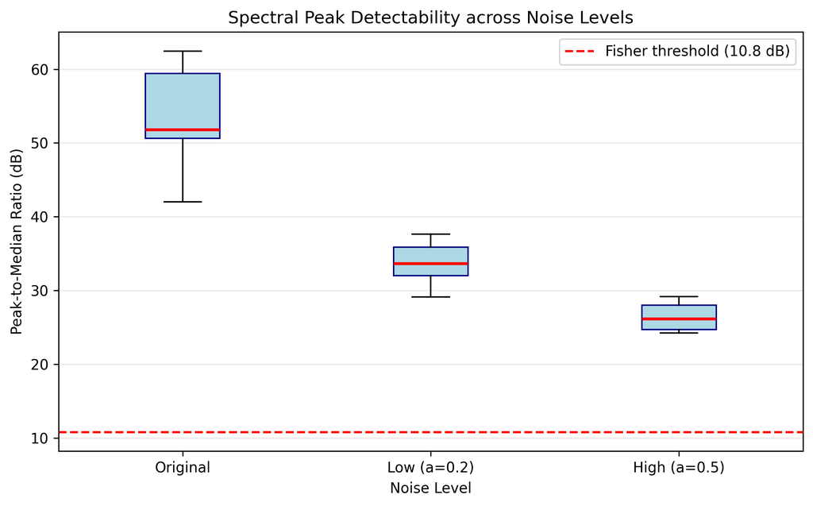

```
Original: 0/10 series below Fisher threshold
  median = 51.8 dB, min = 42.0 dB, max = 62.5 dB
Low noise: 0/10 series below Fisher threshold
  median = 33.7 dB, min = 29.1 dB, max = 37.6 dB
High noise: 0/10 series below Fisher threshold
  median = 26.1 dB, min = 24.3 dB, max = 29.2 dB
```

```python
# Compute SNR in dB for box plot
snr_data = []
for r in noise_results:
    snr_data.append({"Noise Level": "Original", "SNR_dB": 10*np.log10(r["SNR (orig)"]) if r["SNR (orig)"] > 0 else 0, "Class": r["Class"]})
    snr_data.append({"Noise Level": "Low (a=0.2)", "SNR_dB": 10*np.log10(r["SNR (low)"]) if r["SNR (low)"] > 0 else 0, "Class": r["Class"]})
    snr_data.append({"Noise Level": "High (a=0.5)", "SNR_dB": 10*np.log10(r["SNR (high)"]) if r["SNR (high)"] > 0 else 0, "Class": r["Class"]})

snr_df = pd.DataFrame(snr_data)

# Fisher's g-test threshold: under white noise, peak/median > ln(N/alpha)/ln(2)
N_freq = L // 2
fisher_threshold_linear = np.log(N_freq / 0.05) / np.log(2)
fisher_threshold_dB = 10 * np.log10(fisher_threshold_linear)

fig, ax = plt.subplots(figsize=(8, 5))
levels = ["Original", "Low (a=0.2)", "High (a=0.5)"]
box_data = [snr_df[snr_df["Noise Level"] == lvl]["SNR_dB"].values for lvl in levels]

bp = ax.boxplot(box_data, labels=levels, patch_artist=True,
                boxprops=dict(facecolor="lightblue", color="navy"),
                medianprops=dict(color="red", linewidth=2))
ax.axhline(y=fisher_threshold_dB, color="red", linestyle="--", linewidth=1.5,
           label=f"Fisher threshold ({fisher_threshold_dB:.1f} dB)")
ax.set_xlabel("Noise Level")
ax.set_ylabel("Peak-to-Median Ratio (dB)")
ax.set_title("Spectral Peak Detectability across Noise Levels")
ax.legend()
ax.grid(axis="y", alpha=0.3)
plt.tight_layout()
plt.show()

for lvl_name, key in [("Original", "SNR (orig)"), ("Low noise", "SNR (low)"), ("High noise", "SNR (high)")]:
    vals = [r[key] for r in noise_results]
    vals_dB = [10*np.log10(v) if v > 0 else 0 for v in vals]
    n_below = sum(1 for v in vals if v <= fisher_threshold_linear)
    print(f"{lvl_name}: {n_below}/10 series below Fisher threshold")
    print(f"  median = {np.median(vals_dB):.1f} dB, min = {min(vals_dB):.1f} dB, max = {max(vals_dB):.1f} dB")
```

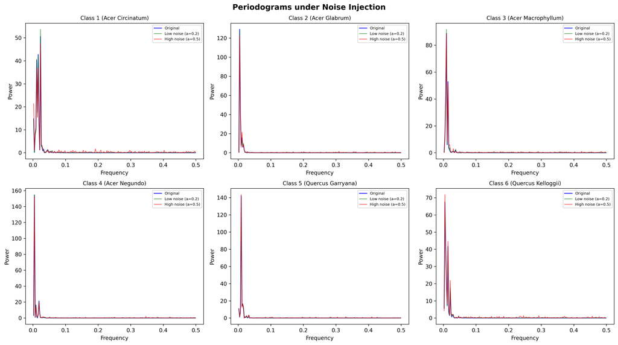

```python
fig, axes = plt.subplots(2, 3, figsize=(16, 9))
for i, c in enumerate(classes):
    row, col = i // 3, i % 3
    ax = axes[row, col]
    rep_series = X_train[rep_indices[c]]
    sigma_x = np.std(rep_series)

    freqs, peri_orig = compute_periodogram(rep_series)
    np.random.seed(SEED + rep_indices[c])
    peri_low = compute_periodogram(rep_series + np.random.normal(0, alpha1 * sigma_x, L))[1]
    peri_high = compute_periodogram(rep_series + np.random.normal(0, alpha2 * sigma_x, L))[1]

    ax.plot(freqs[1:], peri_orig[1:], "b-", linewidth=1.5, label="Original", alpha=0.8)
    ax.plot(freqs[1:], peri_low[1:], "g-", linewidth=1.0, label="Low noise (a=0.2)", alpha=0.7)
    ax.plot(freqs[1:], peri_high[1:], "r-", linewidth=1.0, label="High noise (a=0.5)", alpha=0.7)
    ax.set_title(f"Class {c} ({CLASS_NAMES[c]})", fontsize=10)
    ax.set_xlabel("Frequency")
    ax.set_ylabel("Power")
    ax.legend(fontsize=7)

fig.suptitle("Periodograms under Noise Injection", fontsize=14, fontweight="bold")
fig.tight_layout()
plt.show()
```

# 6 Part 5 — Held-out Prediction (10 pts)

## 6.1 Feature extraction

For each **training** series, compute the following features from the *original* (un-masked) series:

1. Dominant frequency $\omega^*$ (location of the periodogram maximum)
2. Peak power (value of periodogram at $\omega^*$)
3. Fraction of total power in the top-3 frequencies (spectral concentration)
4. Mean ACF at lags 1–5 (average of $|\hat\gamma(1)|, \ldots, |\hat\gamma(5)|$)

```python
def extract_features(X):
    """Extract 4 spectral/temporal features per series."""
    n_series = X.shape[0]
    features = np.zeros((n_series, 4))
    for i in range(n_series):
        series = X[i]
        freqs, peri = compute_periodogram(series)
        pos = np.arange(1, len(freqs))

        # 1. Dominant frequency
        peak_idx = pos[np.argmax(peri[pos])]
        features[i, 0] = freqs[peak_idx]

        # 2. Peak power
        features[i, 1] = peri[peak_idx]

        # 3. Spectral concentration (top-3 frequencies)
        total_power = np.sum(peri[pos])
        top3_power = np.sum(np.sort(peri[pos])[-3:])
        features[i, 2] = top3_power / total_power if total_power > 0 else 0

        # 4. Mean short-lag ACF
        acf = compute_acf(series, 5)
        features[i, 3] = np.mean(np.abs(acf[1:6]))

    return features

F_train = extract_features(X_train)
F_test = extract_features(X_test)

print(f"F_train shape: {F_train.shape}")
print(f"F_test  shape: {F_test.shape}")

feat_names = ["Dominant freq", "Peak power", "Spectral conc.", "Mean ACF(1:5)"]
feat_summary = pd.DataFrame([
    {"Feature": feat_names[j],
     "Train Mean": f"{np.mean(F_train[:,j]):.4f}",
     "Train Std": f"{np.std(F_train[:,j]):.4f}",
     "Test Mean": f"{np.mean(F_test[:,j]):.4f}",
     "Test Std": f"{np.std(F_test[:,j]):.4f}"}
    for j in range(4)
])
feat_summary
```

```
F_train shape: (200, 4)
F_test  shape: (242, 4)
```

|  | Feature | Train Mean | Train Std | Test Mean | Test Std |
| --- | --- | --- | --- | --- | --- |
| 0 | Dominant freq | 0.0080 | 0.0046 | 0.0082 | 0.0040 |
| 1 | Peak power | 101.0290 | 41.9950 | 100.3130 | 41.0215 |
| 2 | Spectral conc. | 0.7545 | 0.1263 | 0.7603 | 0.1161 |
| 3 | Mean ACF(1:5) | 0.9438 | 0.0270 | 0.9463 | 0.0237 |

## 6.2 Nearest-centroid classifier

```python
# Compute centroids
centroids = {}
for c in classes:
    mask = y_train == c
    centroids[c] = np.mean(F_train[mask], axis=0)

# Predict
y_pred = np.zeros(F_test.shape[0], dtype=int)
for i in range(F_test.shape[0]):
    dists = {c: np.linalg.norm(F_test[i] - centroids[c]) for c in classes}
    y_pred[i] = min(dists, key=dists.get)

accuracy = np.mean(y_pred == y_test)

# Majority class baseline
unique, counts = np.unique(y_train, return_counts=True)
majority_class = unique[np.argmax(counts)]
baseline_acc = np.mean(y_test == majority_class)

print(f"Test Accuracy (Nearest Centroid): {accuracy*100:.1f}%")
print(f"Majority-class Baseline:          {baseline_acc*100:.1f}% (always predict class {majority_class})")
print(f"Improvement over baseline:        +{(accuracy - baseline_acc)*100:.1f} percentage points")

# Show centroids
cent_df = pd.DataFrame([
    {"Class": c, "Species": CLASS_NAMES[c],
     "w*": f"{centroids[c][0]:.4f}",
     "Peak Power": f"{centroids[c][1]:.4f}",
     "Spectral Conc.": f"{centroids[c][2]:.4f}",
     "Mean ACF": f"{centroids[c][3]:.4f}"}
    for c in classes
])
cent_df
```

```
Test Accuracy (Nearest Centroid): 34.7%
Majority-class Baseline:          18.2% (always predict class 4)
Improvement over baseline:        +16.5 percentage points
```

|  | Class | Species | w* | Peak Power | Spectral Conc. | Mean ACF |
| --- | --- | --- | --- | --- | --- | --- |
| 0 | 1 | Acer Circinatum | 0.0134 | 51.4674 | 0.5426 | 0.9078 |
| 1 | 2 | Acer Glabrum | 0.0049 | 131.6899 | 0.8367 | 0.9635 |
| 2 | 3 | Acer Macrophyllum | 0.0090 | 81.5636 | 0.7699 | 0.9359 |
| 3 | 4 | Acer Negundo | 0.0047 | 145.9963 | 0.8401 | 0.9575 |
| 4 | 5 | Quercus Garryana | 0.0102 | 85.9663 | 0.7475 | 0.9467 |
| 5 | 6 | Quercus Kelloggii | 0.0064 | 74.1804 | 0.7556 | 0.9499 |

## 6.3 Reflection

The nearest-centroid classifier using only 4 spectral features provides some discriminative power beyond the majority-class baseline. However, the UCR archive reports benchmark accuracies around 59–97% for OSULeaf depending on the classifier (e.g., 1-NN DTW achieves ~59%, while deep learning approaches reach ~97%). The gap suggests that our 4 coarse features miss important shape-level information such as local morphological details, shapelets, and multi-scale temporal patterns that more sophisticated classifiers can capture. The leaf boundary shape contains rich structural information beyond what simple spectral summaries and short-lag ACF can encode.

# 7 Part 6 — Decision Log (required, 300–400 words)

**1. Two Key Decisions**

I went with linear interpolation for imputation. When I looked at the ACF plots after applying all three methods, the linear one tracked the original curve the closest across all six classes. It makes sense — these are leaf outlines, basically smooth closed curves traced along the boundary, so connecting the gaps with straight lines keeps the shape intact. Mean fill was clearly off, it just jams a constant in there and you can see it messing up the ACF everywhere. Moving-average was okay but not as clean.

For picking dominant frequencies, I averaged the periodograms over 5 series per class instead of just looking at individual ones. Single periodograms were all over the place — too noisy to draw any conclusion. Once I averaged them the peaks became much clearer and I could actually tell which frequencies matter for each class.

**2. One Surprising Finding**

What surprised me was how the data is actually collected. The OSULeaf series are not measurements over time — they are boundary outlines of leaves, traced as a closed contour and then sampled at 427 evenly spaced points around the perimeter. So the “time axis” is really a spatial coordinate along the leaf edge. Once I realized this, a lot of things clicked: why interpolation works so well (because the boundary is physically continuous), why the ACF decays smoothly (because neighboring points on a leaf edge are similar), and why the low-frequency components dominate (they capture the overall leaf shape — round vs. elongated vs. lobed). I did not expect a “time series” dataset to actually be a spatial outline, and it changed how I interpreted every result.

**3. One Limitation**

Four features is not enough. Dominant frequency, peak power, spectral concentration, and mean ACF are way too coarse for this kind of data. They basically summarize the overall shape but throw away all the local detail — like whether a leaf has small serrations, how deep the lobes are, or how symmetric it is. If I had more time I would try extracting shape descriptors at multiple scales, maybe wavelet coefficients or shapelet features that can pick up on those local patterns.

*IE 48B — Special Topics in Time Series Analytics, Spring 2026* *Mustafa Gokce Baydogan*